# Flood Mapping for Urban Disruptions and Emergency Response

Shuya Guan and Riya Saini

## Objectives

As the frequency and severity of extreme weather events escalate due to climate change, urban transportation infrastructure—including highways, rail systems, and bridges—faces increasing exposure to flood-related disruptions. Recent analyses reveal that the global population residing in flood-prone areas has increased by 20% to 24% since the year 2000, a rate significantly higher than previously projected, with climate-related drivers such as intensified rainfall and sea-level rise cited as major contributors (Environmental Defense Fund, n.d.). Despite growing awareness, existing flood risk assessments often lack the spatial resolution and predictive capability required by transportation planners to effectively prioritize adaptation strategies. This study proposes the use of machine learning techniques to classify satellite imagery into flooded and non-flooded categories. The principal objective is to enhance flood detection accuracy using Sentinel satellite data, thereby supporting timely disaster response and advancing climate-resilient transportation planning.

## Problem Scope

This research aims to identify flood-prone areas and facilitate a more targeted approach to risk mitigation. Our analysis that can be overlaid with critical transportation corridors, to highlight infrastructure segments that are most at risk. These insights can be used to inform decisions on infrastructure investment, emergency detour planning, and long-term design adaptations to climate hazards. The urgency of this work is underscored by recent hydrological models projecting a global increase in flooding of 9% to 49% by the end of the 21st century under various climate scenarios (Fathom, 2024). Additionally, compounding factors such as rapid urbanization, outdated drainage systems, and land subsidence are contributing to more frequent and severe flood events (CAF America, 2024). These dynamics necessitate the development of data-driven decision support systems to augment traditional flood management frameworks.

## Target Users

The outputs of this project are intended to serve a range of stakeholders engaged in urban infrastructure and emergency management, particularly those focused on the transportation sector. Key user groups include: Urban and Regional Planners with a focus in integrating flood vulnerablity into long-range infrastructure planning and zoning decisions. Public Transit Agencies with a need for real-time operational decisions such as route suspensions or diversions during flood events. Civil and Transportation Engineers who incorporate flood risk parameters into the design and retrofitting of transportation infrastructure. By equipping these actors with a predictive tools for rapid flood detection, the study aims to improve the resilience and adaptability of transportation systems in the face of intensifying climate risks.

## Dataset Exploration

This project uses the SEN12-FLOOD dataset (DOI: 10.21227/w6xz-s898), which contains 336 time series of Sentinel-1 SAR and Sentinel-2 RGB images collected during major flooding events in the winter of 2019. In total, it includes more than 28,000 labeled images, with 17,961 flooded and 10,333 non-flooded samples. The dataset spans regions in East and South West Africa, the Middle East, and Australia, offering geographic and climatic diversity that strengthens its value as a benchmark for flood detection.

The dataset is organized into numbered folders, each representing a location and time, with binary flood labels. Sentinel-2 provides high-resolution optical imagery with distinct water and land features, while Sentinel-1 contributes radar data but often appears dark and noisy. Given the abundance of Sentinel-2 samples, their RGB composition, and their 10-meter spatial resolution, this project prioritizes Sentinel-2 imagery for CNN-based modeling over the less spectrally rich Sentinel-1 inputs.

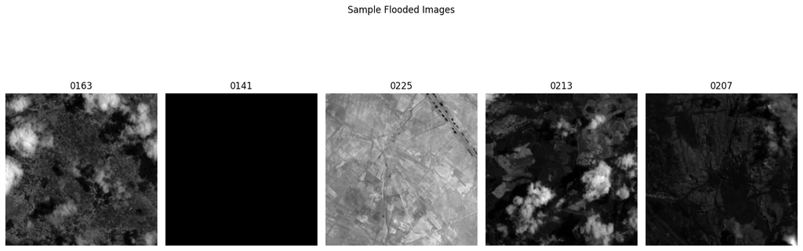

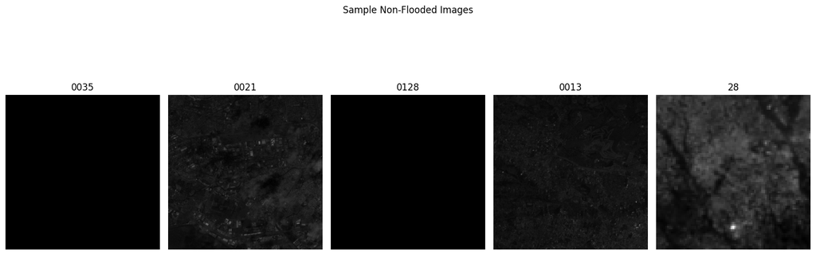

## Data Preprocessing

Preprocessing began with band selection, ensuring that each folder contained aligned B02 (blue), B03 (green), and B04 (red) images captured on the same date to form valid RGB composites. A custom script filtered the dataset, yielding 300 valid folders (about 90 percent of the total). Next, reflectance normalization was applied using percentile-based scaling (2nd–98th percentiles) to enhance contrast while suppressing outliers, converting values into 8-bit RGB images. To address noise, implicit cloud filtering was performed by excluding folders missing usable band alignments, which effectively removed many heavily clouded or corrupted samples.

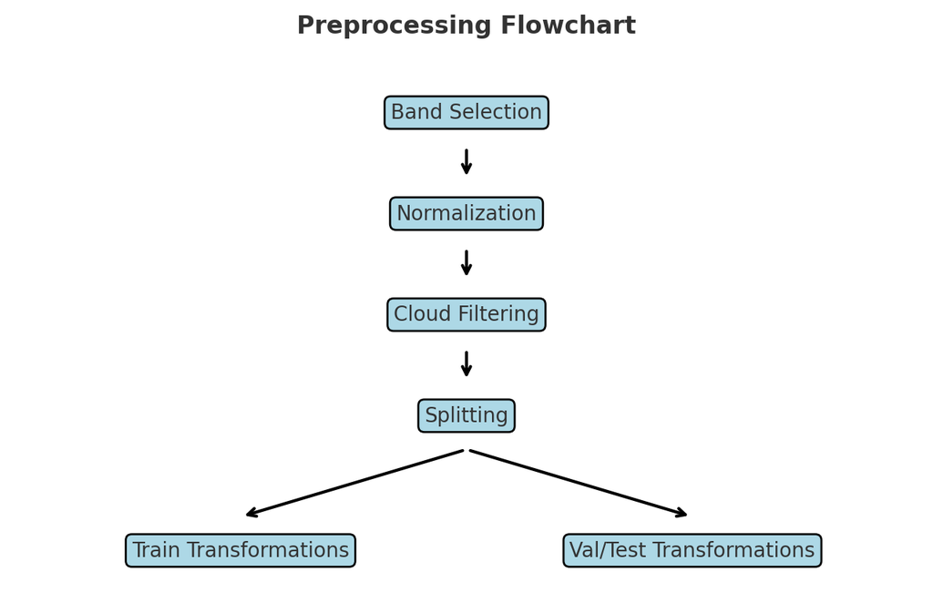

After cleaning, the dataset was split at the folder level to avoid data leakage: 210 folders for training, 45 for validation, and 45 for testing (70/15/15 split). A custom PyTorch dataset class handled image loading and transformations. Training images were resized to 224×224 pixels, normalized to [–1, 1], and augmented with random flips and small rotations to improve robustness. Validation and test images were resized and normalized only, preserving their integrity for unbiased evaluation. Each processed sample was returned as a [3, 224, 224] tensor with a binary label, forming a reliable and consistent pipeline for model development.

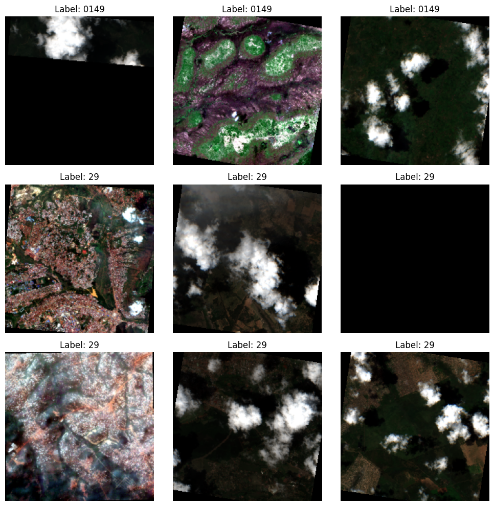

## Model Development

Before building our own CNN, we reviewed two existing approaches to flood detection. UN-SPIDER, a UN-developed tool, uses rule-based thresholds on pre- and post-event Sentinel-1 SAR backscatter to identify floods. It is lightweight and easy to run but struggles with accuracy, particularly in urban or complex landscapes.

By contrast, WorldFloods, developed by Oxford and the Frontier Development Lab, applies a U-Net model to multi-temporal Sentinel-1 SAR data, producing detailed pixel-level flood maps. While highly accurate and resilient to cloud cover, it requires multiple data sources and significant computational power. These two approaches highlight the trade-off between simplicity and performance. Our work aims for a middle ground: a CNN trained solely on Sentinel-2 RGB imagery, balancing ease of deployment with competitive accuracy, especially in settings where multi-modal data and high-end hardware are not available.

[output not shown]

## Model Comparison

On the test set, Random Forest performed worst, with only 46% accuracy and an AUC of 0.56, misclassifying most non-flooded scenes. ResNet improved significantly, reaching 71% accuracy and an F1 score of 0.71, though some class confusion remained. EfficientNet-B0 was the strongest model, achieving 77.8% accuracy, an F1 of 0.78, and an AUC of 0.92. It generalized best, with balanced precision and recall, and handled geographic and visual variation more effectively than the other models.

## Final Model

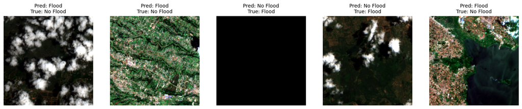

## Conclusion

This project explored flood detection using only Sentinel-2 RGB imagery, moving from a Random Forest baseline to CNNs with ResNet18 and EfficientNet-B0. Results showed the clear advantage of convolutional architectures, with EfficientNet-B0 achieving the best performance and calibration across all metrics. Beyond model accuracy, the project demonstrated a complete pipeline from raw image preprocessing to evaluation, underscoring the potential of deep learning for disaster monitoring and laying groundwork for future extensions with multi-modal or temporal data.

## References

1. Mobley, W., Sebastian, A., Blessing, R., Highfield, W. E., Stearns, L., & Brody, S. D. (2021). Quantification of continuous flood hazard using random forest classification and flood insurance claims at large spatial scales: A pilot study in southeast Texas. Natural Hazards and Earth System Sciences, 21(2), 807–822. https://doi.org/10.5194/nhess-21-807-2021
2. Roy, S. (n.d.). Flood prediction models performance comparison [Kaggle Notebook]. Kaggle. https://www.kaggle.com/code/subhojeetroy01/flood-prediction-models-performance-comparison
3. DanishKaggle78. (n.d.). Flood detection ML project [Kaggle Notebook]. Kaggle. https://www.kaggle.com/code/danishkaggle78/flood-detection-ml-project/notebook
4. CAF America. (2024, September 25). Global flooding crisis 2024: Causes, impact, and relief efforts. https://cafamerica.org/blog/global-flooding-crisis-2024-causes-impact-and-relief-efforts/
5. Environmental Defense Fund. (n.d.). Why are floods hitting more places and people? https://www.edf.org/why-are-floods-hitting-more-places-and-people
6. Fathom. (2024, August 21). Global flooding to increase 9%-49% this century, new study reveals. https://www.fathom.global/newsroom/new-study-reveals-global-flooding-increase/
7. Brown, P. (2024, May 8). Are floods dramatically increasing due to climate change? The Breakthrough Institute. https://thebreakthrough.org/journal/no-20-spring-2024/are-floods-dramatically-increasing-due-to-climate-change